# Computational Techniques

## Motivation and Learning Goals

**Motivation**

- We often read about computations performed in research papers, but it is not always clear how to implement them in practice.

**Learning Goals**

- Learn how to implement computational techniques relevant to this type of research in Julia.

## Nonlinear equations

- An equation solver searches for $x^\ast$ such that

$$F(x^\ast)=0.$$

- In economics, $F$ may represent excess demand, equilibrium conditions, or first-order conditions.

### Bisection

- **Overview:** Bisection is the simplest and most robust method for solving a scalar equation when a bracket is available.
- **Idea:** The intermediate value theorem implies that a continuous function has a root inside an interval satisfying $f(a_0)f(b_0)<0$.
- **Benefits:**
  - It always keeps a root inside the bracket.
  - It does not need derivatives.
- **Costs:**
  - It converges slowly.
  - It needs a scalar equation and a starting bracket.

**Algorithm: Bisection**

- **Input:** A continuous function $f$, a bracket $[a_0,b_0]$, a tolerance $\varepsilon$, and a maximum iteration count $K$.
- **Assumption:** $f(a_0)f(b_0)\leq 0$.

$$[a_{k+1},b_{k+1}]
=
\begin{cases}
[a_k,m_k], & f(a_k)f(m_k)\leq 0,\\
[m_k,b_k], & \text{otherwise},
\end{cases}
\qquad
m_k=\frac{a_k+b_k}{2}.$$

- **Update:** For $k=0,\ldots,K-1$:
  1. Set $m_k=(a_k+b_k)/2$.
  2. Stop and return $m_k$ if $|f(m_k)|\leq\varepsilon$.
  3. Retain the half interval on which the function changes sign.
- **Stop:** Also stop when $(b_k-a_k)/2\leq\varepsilon$.
- **Output:** The approximate root, residual, iteration count, and solver status.
- **Example problem:** find the market-clearing price when demand is $D(p)=10/p$ and supply is $S(p)=5$:

$$\text{find }p^\ast\in[0.5,4]
\quad\text{such that}\quad
F(p^\ast)=\frac{10}{p^\ast}-5=0.$$

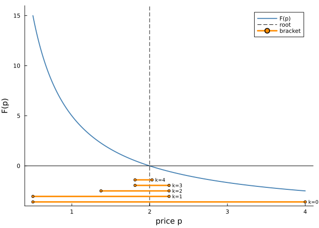

Figure 1: Bisection repeatedly contracts an interval that brackets the root.

```julia
using LinearAlgebra
using ForwardDiff
import Roots

excess_demand(price) = 10 / price - 5

roots_bisection_price = Roots.find_zero(
    excess_demand,
    (0.5, 4.0),
    Roots.Bisection(),
)

roots_bisection_residual = excess_demand(roots_bisection_price)
@show roots_bisection_price roots_bisection_residual
```

```
roots_bisection_price = 2.0
roots_bisection_residual = 0.0
```

```
0.0
```

### Newton’s method

- Bisection needs an interval known to contain a root. When such a bracket is unavailable but derivatives can be evaluated, Newton’s method provides a local alternative.
- **Overview:** Newton’s method is a local root-finding method based on derivatives.
- **Idea:** Replace $F$ by its first-order approximation and use the root of the local linear model as the next iterate.
- **Benefits:**
  - It converges very quickly near a regular root.
  - It works for both scalar equations and systems.
- **Costs:**
  - It needs a derivative or Jacobian.
  - A poor starting value or an unstable Jacobian can cause failure.

**Algorithm: Newton’s method**

- **Input:** $F$, its Jacobian $J_F$, an initial value $x_0$, a tolerance $\varepsilon$, and a maximum iteration count $K$.

$$J_F(x_k)\Delta x_k=-F(x_k),
\qquad
x_{k+1}=x_k+\Delta x_k.$$

- **Update:** For $k=0,\ldots,K-1$:
  1. Solve $J_F(x_k)\Delta x_k=-F(x_k)$.
  2. Set $x_{k+1}=x_k+\Delta x_k$.
  3. Stop if $\lVert F(x_{k+1})\rVert_\infty\leq\varepsilon$.
- **Failure check:** Stop with a failure status if the Newton system cannot be solved reliably.
- **Output:** The approximate root, residual, iteration count, and solver status.
- **Example problem:** solve the same market-clearing equation from $p_0=1$:

$$\text{find }p^\ast>0
\quad\text{such that}\quad
F(p^\ast)=\frac{10}{p^\ast}-5=0.$$

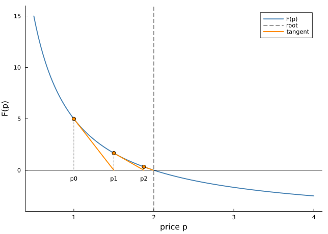

Figure 2: Newton’s method uses the root of each tangent line as the next iterate.

```julia
excess_demand_derivative(price) = -10 / price^2
import Roots

roots_newton_price = Roots.find_zero(
    (excess_demand, excess_demand_derivative),
    1.0,
    Roots.Newton(),
)

roots_newton_residual = excess_demand(roots_newton_price)
@show roots_newton_price roots_newton_residual
```

```
roots_newton_price = 2.0
roots_newton_residual = 0.0
```

```
0.0
```

- For larger systems, `NLsolve.jl` and `NonlinearSolve.jl` construct or approximate the Jacobian and solve the Newton system.

### Broyden method

- Newton’s method repeatedly evaluates or constructs the Jacobian. When that calculation is expensive, Broyden’s method replaces it with an updated approximation.
- **Overview:** Broyden’s method is a quasi-Newton root finder that avoids recomputing the full Jacobian at every iteration.
- **Idea:** Use successive changes in $x$ and $F(x)$ to update a Jacobian approximation $B_k$ through a secant condition.
- **Benefits:**
  - It does not rebuild the full Jacobian at every step.
  - It is useful when computing the Jacobian is expensive.
- **Costs:**
  - The Jacobian approximation can become inaccurate.
  - It can be less reliable than Newton’s method.

**Algorithm: Broyden’s method**

- **Input:** $F$, an initial value $x_0$, an initial Jacobian approximation $B_0$, a tolerance $\varepsilon$, and a maximum iteration count $K$.
- Set $s_k=x_{k+1}-x_k$ and $y_k=F(x_{k+1})-F(x_k)$, and update:

$$B_{k+1}
=
B_k+\frac{(y_k-B_ks_k)s_k'}{s_k's_k}.$$

- **Update:** For $k=0,\ldots,K-1$:
  1. Solve $B_ks_k=-F(x_k)$ and set $x_{k+1}=x_k+s_k$.
  2. Stop if $\lVert F(x_{k+1})\rVert_\infty\leq\varepsilon$.
  3. Set $y_k=F(x_{k+1})-F(x_k)$.
  4. Use $(s_k,y_k)$ to update $B_k$ by the rank-one formula above.
- **Failure check:** Stop if the approximate Newton system cannot be solved or if the rank-one update becomes numerically unstable.
- **Output:** The approximate root, residual, iteration count, and solver status.
- **Example problem:** solve a two-equation nonlinear system from $x_0=(5,1.5)'$:

$$\text{find }x^\ast=
\begin{bmatrix}
x_1^\ast\\
x_2^\ast
\end{bmatrix}
\quad\text{such that}\quad
F(x^\ast)=
\begin{bmatrix}
(x_1^\ast)^2+x_2^\ast-37\\
x_1^\ast-(x_2^\ast)^2-5
\end{bmatrix}
=
\begin{bmatrix}
0\\
0
\end{bmatrix}.$$

```julia
import NonlinearSolve

equilibrium_system(x) = [
    x[1]^2 + x[2] - 37,
    x[1] - x[2]^2 - 5,
]

broyden_problem = NonlinearSolve.NonlinearProblem(
    (x, _) -> equilibrium_system(x),
    [5.0, 1.5],
)
broyden_result = NonlinearSolve.solve(
    broyden_problem,
    NonlinearSolve.Broyden(init_jacobian = Val(:true_jacobian));
    abstol = 1e-10,
    reltol = 1e-10,
    maxiters = 100,
)

broyden_solution = broyden_result.u
broyden_residual = equilibrium_system(broyden_solution)
broyden_status = broyden_result.retcode
@show broyden_solution broyden_residual broyden_status
```

```
broyden_solution = [5.999999999999929, 0.9999999999999457]
broyden_residual = [-9.094947017729282e-13, 3.730349362740526e-14]
broyden_status = SciMLBase.ReturnCode.Success
```

```
ReturnCode.Success = 1
```

- `NonlinearSolve.jl` provides `Broyden()` and `LimitedMemoryBroyden()`.

### Fixed-point iteration

- Broyden treats the system as $F(x)=0$. If the same problem has a useful fixed-point form $x=G(x)$, fixed-point iteration directly applies that mapping.
- **Overview:** Fixed-point iteration repeatedly applies a mapping to solve $x=G(x)$.
- **Idea:** Start from $x_0$ and use the current output as the next input.
- **Benefits:**
  - It is simple and does not need derivatives.
  - It works well when the mapping is a contraction.
- **Costs:**
  - A poor choice of the mapping can cause divergence.
  - Convergence can be slow.

**Algorithm: Fixed-point iteration**

- **Input:** A mapping $G$, an initial value $x_0$, a tolerance $\varepsilon$, and a maximum iteration count $K$.
- **Update:** For $k=0,\ldots,K-1$, set:

$$x_{k+1}=G(x_k).$$

- Stop if $\lVert x_{k+1}-x_k\rVert_\infty\leq\varepsilon$.
- If the full update is unstable, use a damping parameter $\lambda\in(0,1]$:

$$x_{k+1}=(1-\lambda)x_k+\lambda G(x_k).$$

- **Output:** The approximate fixed point, iteration count, and solver status.
- **Example problem:** find the fixed point of the cosine function:

$$\text{find }x^\ast
\quad\text{such that}\quad
x^\ast=\cos(x^\ast).$$

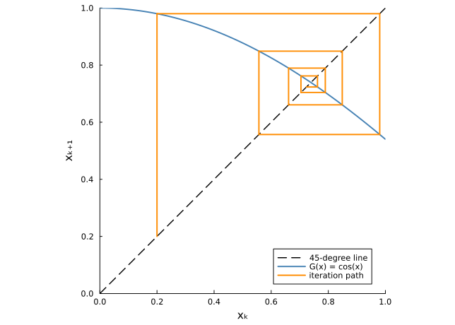

Figure 3: Each vertical step applies G(x) = cos(x), and each horizontal step carries the output to the 45-degree line.

```julia
import NLsolve

fixed_point_result = NLsolve.fixedpoint(
    value -> cos.(value),
    [1.0];
    inplace = false,
    xtol = 1e-10,
    ftol = 1e-10,
)

fixed_point_solution = only(fixed_point_result.zero)
fixed_point_residual =
    only(cos.(fixed_point_result.zero) - fixed_point_result.zero)
fixed_point_converged = NLsolve.converged(fixed_point_result)
@show fixed_point_solution fixed_point_residual fixed_point_converged
```

```
fixed_point_solution = 0.7390851332151607
fixed_point_residual = 0.0
fixed_point_converged = true
```

```
true
```

### Gauss–Jacobi iteration

- Fixed-point iteration gives the general update $x_{k+1}=G(x_k)$. For a vector mapping, Gauss–Jacobi computes every component of the next vector simultaneously.
- **Overview:** Gauss–Jacobi is a simultaneous fixed-point method for a vector equation $x=G(x)$.
- **Idea:** Compute every new component from the same old vector $x_k$.
- **Benefits:**
  - The components can be updated in parallel.
  - The component order does not affect the update.
- **Costs:**
  - It may require many iterations.
  - It can fail when the mapping is not contractive.

**Algorithm: Gauss–Jacobi iteration**

- **Input:** A mapping $G:\mathbb{R}^n\rightarrow\mathbb{R}^n$, an initial value $x_0$, a tolerance $\varepsilon$, and a maximum iteration count $K$.
- **Update:** For $k=0,\ldots,K-1$, compute all components from $x_k$:

$$x_{i,k+1}
=
G_i(x_{1,k},\ldots,x_{n,k}),
\qquad i=1,\ldots,n.$$

- Replace $x_k$ only after all new components have been computed.
- Stop if $\lVert x_{k+1}-x_k\rVert_\infty\leq\varepsilon$.
- **Output:** The approximate fixed point, iteration count, and solver status.
- **Example problem:** find the Cournot equilibrium by updating both firms’ quantities at the same time.
- Let $P=10-(q_1+q_2)$ and $C_i(q_i)=2q_i$. Each firm’s best response is:

$$\operatorname{BR}_i(q_j)
=
\max\left\{0,\frac{8-q_j}{2}\right\}.$$

- The equilibrium solves:

$$\text{find }(q_1^\ast,q_2^\ast)
\quad\text{such that}\quad
\begin{cases}
q_1^\ast=\operatorname{BR}_1(q_2^\ast),\\
q_2^\ast=\operatorname{BR}_2(q_1^\ast).
\end{cases}$$

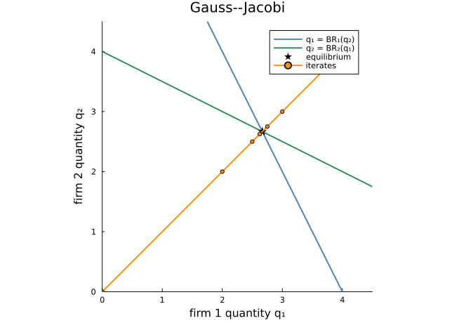

Figure 4: Gauss–Jacobi computes both best responses from the old quantities.

```julia
best_response(other_quantity; demand_intercept = 10.0, slope = 1.0, cost = 2.0) =
    max(0.0, (demand_intercept - cost - slope * other_quantity) / (2slope))

function cournot_jacobi(initial_value; atol = 1e-10, maxiter = 1_000)
    quantities = copy(initial_value)
    for iteration in 1:maxiter
        new_quantities = [
            best_response(quantities[2]),
            best_response(quantities[1]),
        ]
        norm(new_quantities - quantities, Inf) <= atol &&
            return new_quantities
        quantities = new_quantities
    end
    error("Gauss--Jacobi iteration did not converge.")
end

cournot_jacobi_solution = cournot_jacobi([0.0, 0.0])
@show cournot_jacobi_solution
```

```
cournot_jacobi_solution = [2.666666666686069, 2.666666666686069]
```

```
2-element Vector{Float64}:
 2.666666666686069
 2.666666666686069
```

### Gauss–Seidel iteration

- Gauss–Jacobi waits until every component has been computed before replacing the old vector. Gauss–Seidel instead uses each new component immediately.
- **Overview:** Gauss–Seidel is a sequential fixed-point method for a vector equation $x=G(x)$.
- **Idea:** Use each new component as soon as it has been computed.
- **Benefits:**
  - Each update uses the newest available values.
  - It often needs fewer iterations than Gauss–Jacobi.
- **Costs:**
  - The path can depend on the component order.
  - The sequential updates are harder to parallelize.

**Algorithm: Gauss–Seidel iteration**

- **Input:** A mapping $G:\mathbb{R}^n\rightarrow\mathbb{R}^n$, an initial value $x_0$, a tolerance $\varepsilon$, and a maximum iteration count $K$.
- **Update:** For $k=0,\ldots,K-1$, update components in order:

$$x_{i,k+1}
=
G_i(
x_{1,k+1},\ldots,x_{i-1,k+1},
x_{i,k},\ldots,x_{n,k}
),
\qquad i=1,\ldots,n.$$

- Stop if $\lVert x_{k+1}-x_k\rVert_\infty\leq\varepsilon$.
- **Output:** The approximate fixed point, iteration count, and solver status.
- **Example problem:** solve the same Cournot system, but update firm 2 after updating firm 1:

$$q_{1,k+1}=\operatorname{BR}_1(q_{2,k}),
\qquad
q_{2,k+1}=\operatorname{BR}_2(q_{1,k+1}).$$

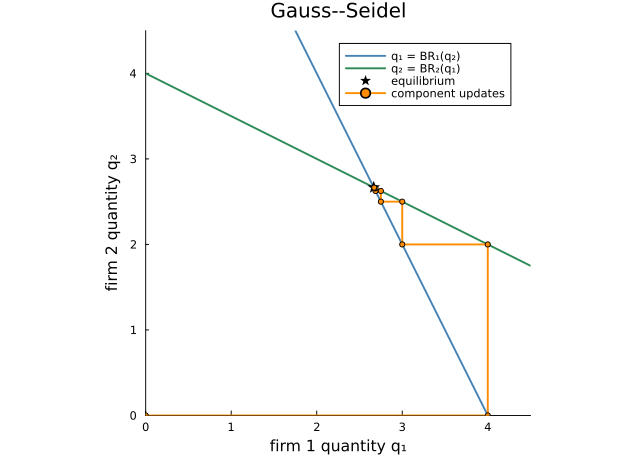

Figure 5: Gauss–Seidel uses firm 1’s new quantity when it updates firm 2.

```julia
function cournot_gauss_seidel(initial_value; atol = 1e-10, maxiter = 1_000)
    quantities = copy(initial_value)
    for iteration in 1:maxiter
        new_q1 = best_response(quantities[2])
        new_q2 = best_response(new_q1)
        new_quantities = [new_q1, new_q2]
        norm(new_quantities - quantities, Inf) <= atol &&
            return new_quantities
        quantities = new_quantities
    end
    error("Gauss--Seidel iteration did not converge.")
end

cournot_gauss_seidel_solution = cournot_gauss_seidel([0.0, 0.0])
@show cournot_gauss_seidel_solution
```

```
cournot_gauss_seidel_solution = [2.666666666686069, 2.6666666666569654]
```

```
2-element Vector{Float64}:
 2.666666666686069
 2.6666666666569654
```

### Choosing a method

#### Suggested starting point

- The tree summarizes the choice after the methods above have been introduced.

```
%%{init: {"themeVariables": {"fontSize": "20px"}, "flowchart": {"nodeSpacing": 30, "rankSpacing": 35}}}%%
flowchart LR
    A["Solve F(x) = 0"] --> B(["Scalar or system?"])
    B -->|Scalar| C(["Bracket available?"])
    C -->|Yes| D["Bisection"]
    C -->|No| E["Newton"]
    B -->|System| F(["Natural fixed-point form?"])
    F -->|Yes| G["Fixed-point iteration,<br/>Gauss--Jacobi, or Gauss--Seidel"]
    F -->|No| H(["Jacobian available?"])
    H -->|Yes| I["Newton"]
    H -->|No| J["Broyden"]
```

- Fixed-point methods require an appropriate mapping $G$.

#### Benefits and costs

| Method | Benefits | Costs |
| --- | --- | --- |
| Bisection | Robust and derivative-free | Slow; requires a scalar bracket |
| Newton | Fast near a regular root; handles systems | Requires derivatives or a Jacobian |
| Broyden | Avoids rebuilding the full Jacobian | The Jacobian approximation may deteriorate |
| Fixed-point iteration | Simple and derivative-free | Convergence depends on the mapping |
| Gauss–Jacobi | Allows parallel component updates | Can be slow; requires a contractive mapping |
| Gauss–Seidel | Uses new component values immediately | Sequential and sensitive to update order |

## Unconstrained optimization

- An unconstrained optimizer searches for:

$$\theta^\ast=\arg\min_{\theta\in\mathbb{R}^p}Q(\theta).$$

- At an interior solution, $\nabla Q(\theta^\ast)=0$.
- Optimization uses equation-solving methods but must distinguish minima, maxima, and saddle points.

### Newton–Raphson

- Newton’s root-finding method solves first-order conditions. For optimization, the same local approximation is applied to $\nabla Q(\theta^\ast)=0$, with the Hessian providing the Jacobian.
- **Overview:** Newton–Raphson is a second-order optimization method that uses the gradient and Hessian.
- **Idea:** Minimize a local quadratic approximation to the objective at each iterate.
- **Benefits:**
  - It can converge very quickly near the optimum.
  - The Hessian uses curvature information directly.
- **Costs:**
  - Building and solving with the Hessian can be expensive.
  - An indefinite Hessian can give a poor direction.

**Algorithm: Newton–Raphson optimization**

- **Input:** $Q$, its gradient and Hessian, an initial value $\theta_0$, a tolerance $\varepsilon$, and a maximum iteration count $K$.
- Use the local quadratic approximation:

$$Q(\theta_k+s)
\approx
Q(\theta_k)
+\nabla Q(\theta_k)'s
+\frac{1}{2}s'H(\theta_k)s.$$

- Solve for the Newton step:

$$H(\theta_k)s_k=-\nabla Q(\theta_k).$$

- **Update:** Set $\theta_{k+1}=\theta_k+s_k$.
- **Stop:** Return $\theta_{k+1}$ when $\lVert\nabla Q(\theta_{k+1})\rVert_\infty\leq\varepsilon$.
- **Failure check:** Stop or safeguard the step if the Hessian system cannot be solved reliably.
- **Output:** The approximate minimizer, objective value, gradient norm, iteration count, and solver status.
- **Illustration:** hold the mean fixed and consider the one-dimensional objective

$$q(\eta)=\eta+2\exp(-2\eta),
\qquad
\eta^\ast=\log 2.$$

- Starting from $\eta_0=1$, Newton–Raphson minimizes the local quadratic approximation to obtain $\eta_1$.

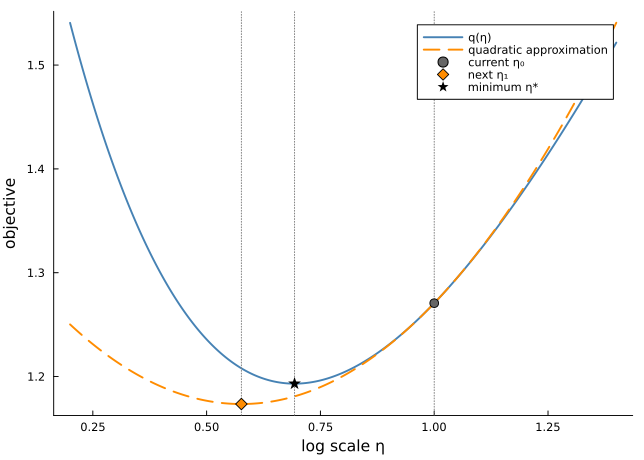

Figure 6: Newton–Raphson uses the minimizer of the local quadratic approximation as the next iterate.

- **Example problem:** for observations $y_1,\ldots,y_n$, minimize the average negative Gaussian log-likelihood up to an additive constant.
- Use $\eta=\log\sigma$ so that $\sigma$ remains positive:

$$\min_{\mu,\eta\in\mathbb{R}}
Q(\mu,\eta)
=
\eta
+\frac{1}{2n\exp(2\eta)}
\sum_{i=1}^n(y_i-\mu)^2,
\qquad
\eta=\log\sigma.$$

```julia
using Random
using Statistics
using Optim

Random.seed!(1234)
sample = 1.5 .+ 0.8 .* randn(500)

function normal_negative_log_likelihood(parameters)
    mean_parameter, log_standard_deviation = parameters
    centered = sample .- mean_parameter
    return log_standard_deviation +
           sum(abs2, centered) /
           (2length(sample) * exp(2log_standard_deviation))
end

function likelihood_gradient!(storage, parameters)
    storage .= ForwardDiff.gradient(normal_negative_log_likelihood, parameters)
    return storage
end

function likelihood_hessian!(storage, parameters)
    storage .= ForwardDiff.hessian(normal_negative_log_likelihood, parameters)
    return storage
end

initial_parameters = [0.0, 0.0]
newton_result = Optim.optimize(
    normal_negative_log_likelihood,
    likelihood_gradient!,
    likelihood_hessian!,
    initial_parameters,
    Optim.Newton(),
)

newton_estimate = Optim.minimizer(newton_result)
newton_analytical_solution = [
    mean(sample),
    log(std(sample; corrected = false)),
]
@show newton_estimate newton_analytical_solution
```

```
newton_estimate = [1.4235855037867489, -0.14535454625277186]
newton_analytical_solution = [1.4235855036508538, -0.1453545458141886]
```

```
2-element Vector{Float64}:
  1.4235855036508538
 -0.1453545458141886
```

### Quasi-Newton methods

- Newton–Raphson requires a new Hessian calculation and linear solve at each iteration. Quasi-Newton methods reduce this cost by approximating curvature from successive gradients.
- **Overview:** Quasi-Newton methods use gradient changes to approximate the inverse Hessian instead of calculating the Hessian directly.
- **Idea:** For

$$s_k=\theta_{k+1}-\theta_k,
\qquad
y_k=\nabla Q(\theta_{k+1})-\nabla Q(\theta_k),$$

update an inverse-Hessian approximation $H_{k+1}$ so that

$$H_{k+1}y_k=s_k.$$

- **Benefits:**
  - They do not need the full Hessian.
  - They are usually a practical default for smooth estimation problems.
- **Costs:**
  - They depend on good scaling and a good line search.
- The two methods differ mainly in how they represent $H_k$:
  - **BFGS:** stores and updates the full $p\times p$ matrix. It uses $O(p^2)$ memory and is useful for moderate $p$.
  - **L-BFGS:** stores only the most recent $m$ pairs $(s_i,y_i)$. It uses $O(mp)$ memory and is useful when $p$ is large.
- **Example problem:** use both methods to minimize the Gaussian objective $Q(\mu,\eta)$ from $(\mu_0,\eta_0)=(0,0)$.

```julia
bfgs_result = Optim.optimize(
    normal_negative_log_likelihood,
    initial_parameters,
    Optim.BFGS();
    autodiff = :forward,
)

lbfgs_result = Optim.optimize(
    normal_negative_log_likelihood,
    initial_parameters,
    Optim.LBFGS();
    autodiff = :forward,
)

bfgs_solution = Optim.minimizer(bfgs_result)
lbfgs_solution = Optim.minimizer(lbfgs_result)
@show bfgs_solution lbfgs_solution
```

```
bfgs_solution = [1.4235855036481526, -0.14535454580261964]
lbfgs_solution = [1.4235855033410831, -0.1453545430113449]
```

```
2-element Vector{Float64}:
  1.4235855033410831
 -0.1453545430113449
```

### Golden-section search

- Newton and quasi-Newton methods use derivatives in multivariate problems. For a bounded scalar problem without derivatives, golden-section search contracts the interval directly.
- **Overview:** Golden-section search is a bounded, derivative-free method for minimizing a scalar objective.
- **Idea:** Place interior points using the golden ratio so that one previous function evaluation can be reused after the interval contracts.
- **Benefits:**
  - It does not need derivatives.
  - After initialization, each step needs only one new function evaluation.
- **Costs:**
  - It needs a bounded, unimodal scalar problem.
  - It is slower than a good derivative-based method.

**Algorithm: Golden-section search**

- **Input:** A scalar objective $q$, an interval $[a_0,b_0]$, a tolerance $\varepsilon$, and a maximum iteration count $K$.
- Set

$$\tau=\frac{\sqrt{5}-1}{2},
\qquad
c_k=b_k-\tau(b_k-a_k),
\qquad
d_k=a_k+\tau(b_k-a_k).$$

- Update the interval by

$$[a_{k+1},b_{k+1}]
=
\begin{cases}
[a_k,d_k], & q(c_k)\leq q(d_k),\\
[c_k,b_k], & q(c_k)>q(d_k).
\end{cases}$$

- The identity $1-\tau=\tau^2$ makes one old interior point an interior point of the new interval, so each update requires only one new evaluation.
- Stop when $b_k-a_k\leq\varepsilon$ and return $(a_k+b_k)/2$.
- **Output:** The approximate minimizer, objective value, iteration count, and solver status.
- **Example problem:** hold $\eta=\log\widehat{\sigma}$ fixed and minimize the profile objective over a bounded interval:

$$\min_{\mu\in[-1,4]}
Q\left(\mu,\log\widehat{\sigma}\right),
\qquad
\widehat{\sigma}
=
\left[
\frac{1}{n}\sum_{i=1}^n(y_i-\overline{y})^2
\right]^{1/2}.$$

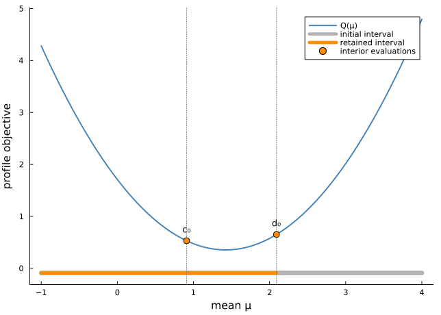

Figure 7: Golden-section search compares two interior points and retains the interval that can contain the minimizer.

```julia
profile_objective(mean_parameter) =
    normal_negative_log_likelihood([
        mean_parameter,
        log(std(sample; corrected = false)),
    ])

golden_result = Optim.optimize(
    profile_objective,
    -1.0,
    4.0,
    Optim.GoldenSection(),
)

golden_solution = Optim.minimizer(golden_result)
@show golden_solution
```

```
golden_solution = 1.4235855073024446
```

```
1.4235855073024446
```

### Nelder–Mead

- Golden-section search is derivative-free but restricted to one dimension. Nelder–Mead extends derivative-free local search to a small multivariate problem by moving a simplex.
- **Overview:** Nelder–Mead is a derivative-free multivariate method that searches with a simplex.
- **Idea:** Move and reshape the simplex through reflection, expansion, contraction, and shrinkage according to the vertex objective values.
- **Benefits:**
  - It does not need derivatives.
  - It is simple and useful in low dimensions.
- **Costs:**
  - It scales poorly as dimension grows.
  - It may stop without reaching a good minimum.

**Algorithm: Nelder–Mead**

- **Input:** An objective $Q$, an initial simplex with $p+1$ vertices, a parameter tolerance $\varepsilon_x$, an objective tolerance $\varepsilon_Q$, and a maximum iteration count $K$.
- Order the vertices so that

$$Q(x_1)\leq Q(x_2)\leq\cdots\leq Q(x_{p+1}),
\qquad
\bar{x}=\frac{1}{p}\sum_{i=1}^p x_i.$$

- With $(\alpha,\gamma,\rho,\sigma)=(1,2,1/2,1/2)$, form

$$\begin{aligned}
x_r&=\bar{x}+\alpha(\bar{x}-x_{p+1}),\\
x_e&=\bar{x}+\gamma(x_r-\bar{x}),\\
x_c^{\mathrm{out}}&=\bar{x}+\rho(x_r-\bar{x}),\\
x_c^{\mathrm{in}}&=\bar{x}+\rho(x_{p+1}-\bar{x}).
\end{aligned}$$

- If $Q(x_1)\leq Q(x_r)<Q(x_p)$, replace $x_{p+1}$ by $x_r$.
- If $Q(x_r)<Q(x_1)$, replace $x_{p+1}$ by the lower-objective point among $x_r$ and $x_e$.
- If $Q(x_p)\leq Q(x_r)<Q(x_{p+1})$, replace $x_{p+1}$ by $x_c^{\mathrm{out}}$ only when $Q(x_c^{\mathrm{out}})\leq Q(x_r)$.
- If $Q(x_r)\geq Q(x_{p+1})$, replace $x_{p+1}$ by $x_c^{\mathrm{in}}$ only when $Q(x_c^{\mathrm{in}})<Q(x_{p+1})$.
- If the applicable contraction condition fails, shrink:

$$x_i\leftarrow x_1+\sigma(x_i-x_1),
\qquad i=2,\ldots,p+1.$$

- Stop when both

$$\max_i\lVert x_i-x_1\rVert_\infty\leq\varepsilon_x,
\qquad
\max_i\left|Q(x_i)-Q(x_1)\right|\leq\varepsilon_Q.$$

- **Output:** The approximate minimizer, objective value, iteration count, and solver status.
- **Example problem:** minimize the same Gaussian objective from $(\mu_0,\eta_0)=(0,0)$:

$$\min_{(\mu,\eta)\in\mathbb{R}^2}Q(\mu,\eta).$$

```
[ Info: Saved animation to /var/folders/gc/pc_l42xd6gsbb4whn77v4x2h0000gn/T/jl_kzsnAhUzYZ.gif
```

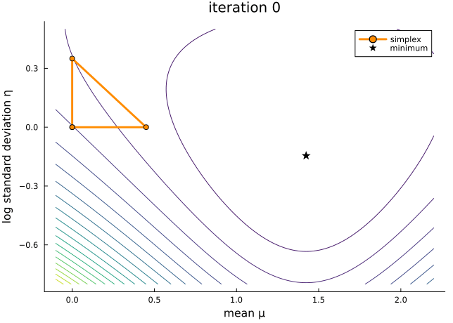

Figure 8: Nelder–Mead moves and reshapes the simplex as the objective value falls.

```julia
nelder_mead_result = Optim.optimize(
    normal_negative_log_likelihood,
    initial_parameters,
    Optim.NelderMead(),
)

nelder_mead_solution = Optim.minimizer(nelder_mead_result)
@show nelder_mead_solution
```

```
nelder_mead_solution = [1.4236164118327652, -0.14530934532284384]
```

```
2-element Vector{Float64}:
  1.4236164118327652
 -0.14530934532284384
```

### Choosing a method

#### Suggested starting point

- The tree summarizes the choice after the methods above have been introduced.

```
%%{init: {"themeVariables": {"fontSize": "20px"}, "flowchart": {"nodeSpacing": 30, "rankSpacing": 35}}}%%
flowchart LR
    A["Minimize Q(theta)"] --> B(["One dimension?"])
    B -->|Yes| C(["Derivative available?"])
    C -->|Yes| D["Newton"]
    C -->|No| E["Golden-section search"]
    B -->|No| F(["Gradient available?"])
    F -->|Yes| G(["Large parameter vector?"])
    G -->|Yes| H["L-BFGS"]
    G -->|No| I["BFGS or Newton"]
    F -->|No| J(["Local search?"])
    J -->|Yes| K["Nelder--Mead"]
    J -->|No| L["Global optimization"]
```

#### Benefits and costs

| Method | Benefits | Costs |
| --- | --- | --- |
| Newton–Raphson | Fast near the optimum; uses curvature directly | Requires a Hessian |
| BFGS | Reliable default without a direct Hessian | Uses quadratic memory; depends on scaling |
| L-BFGS | Uses little memory in large problems | Retains less curvature information |
| Golden-section search | Derivative-free and evaluation-efficient | Limited to bounded, unimodal scalar problems |
| Nelder–Mead | Simple and derivative-free | Scales poorly with dimension |

## Constrained optimization

- A constrained problem takes the form:

$$\begin{aligned}
\min_x \quad & f(x) \\
\text{subject to}\quad
& g_j(x)=0, \\
& h_\ell(x)\leq 0.
\end{aligned}$$

- The Karush–Kuhn–Tucker conditions combine:
  - stationarity;
  - feasibility; and
  - complementary slackness.
- These conditions connect constrained optimization to systems of equations and complementarity problems.

### Modeling Language: JuMP

- Unconstrained methods operate directly on an objective. Once constraints are added, JuMP provides a common way to state the full problem before choosing a compatible solver.
- **Overview:** JuMP is a modeling language that represents an optimization problem separately from the numerical solver.
- **Idea:** Express variables, objectives, and constraints in mathematical form, then pass the resulting model to a compatible solver.
- **Benefits:**
  - The model stays separate from the solver.
  - It can provide solver status, values, and dual information.
- **Costs:**
  - You still need to choose the right solver.
  - You still need to check convergence and feasibility.

**Workflow: Solve and verify a constrained model**

- **Model:** Declare the variables, objective, and constraints.
- **Solver:** Choose a solver that matches the mathematical structure of the problem.
- **Solve:** Call `optimize!` and record the termination status.
- **Verify:** Check primal feasibility and the objective value before using the solution.
- **Interpret:** Inspect active constraints, dual values, and complementary slackness when they have an economic interpretation.

#### Example: JuMP grammar

```julia
using JuMP

model = Model(Solver.Optimizer)
@variable(model, x >= 0)
@objective(model, Min, objective_expression)
@constraint(model, constraint_expression <= 0)
optimize!(model)
```

### Solvers: HiGHS and Ipopt

- HiGHS and Ipopt are the two best starting points for this course because they cover the main constrained problem classes while using the same JuMP model interface.

| Solver | Use it for | Benefits | Costs |
| --- | --- | --- | --- |
| HiGHS | Linear, mixed-integer linear, and convex quadratic problems | Fast open-source solver for structured problems | Does not solve general nonlinear problems |
| Ipopt | Smooth nonlinear objectives and constraints | Uses first and second derivatives efficiently in large smooth problems | Usually returns a local solution for nonconvex problems |

### Example 1: Linear Programming

- A firm chooses two outputs.
  - Product 1 earns 3 units.
  - Product 2 earns 5 units.
  - Two resource constraints limit production.

$$\begin{aligned}
\max_{x_1,x_2\geq 0}\quad
&3x_1+5x_2\\
\text{subject to}\quad
&2x_1+x_2\leq 100,\\
&x_1+3x_2\leq 90.
\end{aligned}$$

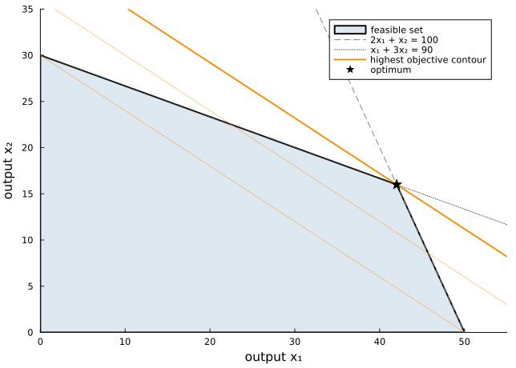

Figure 9: The linear-program optimum occurs at a feasible vertex reached by the highest objective contour.

```julia
using JuMP
using HiGHS

production_model = Model(HiGHS.Optimizer)
set_silent(production_model)

@variable(production_model, output_1 >= 0)
@variable(production_model, output_2 >= 0)
@objective(production_model, Max, 3output_1 + 5output_2)
@constraint(production_model, 2output_1 + output_2 <= 100)
@constraint(production_model, output_1 + 3output_2 <= 90)

optimize!(production_model)

production_status = termination_status(production_model)
production_output = value.([output_1, output_2])
production_profit = objective_value(production_model)
@show production_status production_output production_profit
```

```
production_status = MathOptInterface.OPTIMAL
production_output = [42.0, 16.0]
production_profit = 206.0
```

```
206.0
```

- For a linear program:
  - inspect the solver status; and
  - use dual values to interpret binding constraints.

### Example 2: Utility Maximization Problem

- A consumer chooses two goods under a budget constraint.
- Concave quadratic utility keeps the example within the class of quadratic programs.

$$\begin{aligned}
\max_{x_1,x_2\geq 0}\quad
&8x_1+6x_2-\frac{1}{2}x_1^2-\frac{1}{2}x_2^2\\
\text{subject to}\quad
&2x_1+x_2\leq 10.
\end{aligned}$$

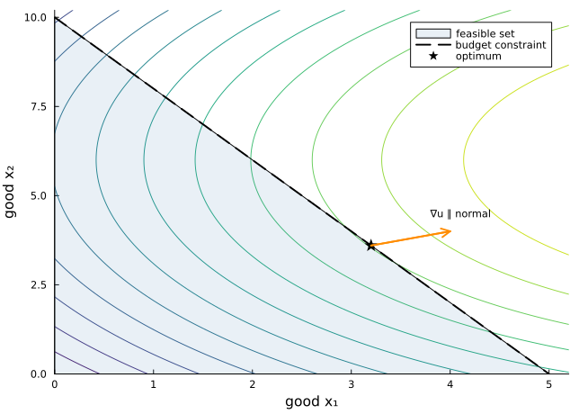

Figure 10: At the constrained consumer optimum, the utility gradient is parallel to the binding budget-constraint normal.

```julia
consumer_model = Model(HiGHS.Optimizer)
set_silent(consumer_model)

@variable(consumer_model, good_1 >= 0)
@variable(consumer_model, good_2 >= 0)
@objective(
    consumer_model,
    Max,
    8good_1 + 6good_2 - 0.5good_1^2 - 0.5good_2^2,
)
@constraint(consumer_model, budget, 2good_1 + good_2 <= 10)

optimize!(consumer_model)

consumer_status = termination_status(consumer_model)
consumer_consumption = value.([good_1, good_2])
consumer_utility = objective_value(consumer_model)
consumer_budget_shadow_price = shadow_price(budget)
@show consumer_status consumer_consumption consumer_utility consumer_budget_shadow_price
```

```
consumer_status = MathOptInterface.OPTIMAL
consumer_consumption = [3.200000079999992, 3.5999998400000157]
consumer_utility = 35.59999999999999
consumer_budget_shadow_price = 2.3999998
```

```
2.3999998
```

- Nonlinear utility functions such as Cobb–Douglas utility can be modeled with JuMP and solved with Ipopt.

## Global Optimization

- A single local optimization run can stop at a local minimum determined by its starting value.
- The methods below increase exploration in three steps: repeated local runs, deterministic partitioning of a bounded domain, and population-based search.

### Multi-start local optimization

- A local solver is fast once it reaches a promising region. Multi-start retains that solver but runs it from many initial values.
- **Overview:** Multi-start repeats local optimization and keeps the solution with the smallest objective value.
- **Idea:** For initial values $\theta_0^{(1)},\ldots,\theta_0^{(M)}$, compute

$$\widehat{\theta}^{(m)}
=
\operatorname{LocalOptimize}\left(Q,\theta_0^{(m)}\right),
\qquad
\widehat{\theta}
=
\arg\min_{\widehat{\theta}^{(m)}}
Q\left(\widehat{\theta}^{(m)}\right).$$

- **Benefits:**
  - It reuses a local solver that is already available.
  - The runs are independent and can be parallelized.
- **Costs:**
  - It can miss regions not covered by the initial values.
  - The total cost grows with the number of starts.
- **Example problem:** minimize the bounded Rastrigin function:

$$\min_{x\in[-5,5]^2}
Q(x)
=
20+\sum_{j=1}^2
\left[
x_j^2-10\cos(2\pi x_j)
\right].$$

```julia
rastrigin_objective(x) =
    20 + sum(value -> value^2 - 10cos(2pi * value), x)

global_lower_bounds = fill(-5.0, 2)
global_upper_bounds = fill(5.0, 2)
multistart_rng = MersenneTwister(3)
multistart_initial_values = [
    global_lower_bounds +
    (global_upper_bounds - global_lower_bounds) .* rand(multistart_rng, 2)
    for _ in 1:20
]

multistart_results = [
    Optim.optimize(
        rastrigin_objective,
        global_lower_bounds,
        global_upper_bounds,
        initial_value,
        Optim.Fminbox(Optim.LBFGS());
        autodiff = :forward,
    )
    for initial_value in multistart_initial_values
]

multistart_objectives = Optim.minimum.(multistart_results)
multistart_best_index = argmin(multistart_objectives)
multistart_best_solution =
    Optim.minimizer(multistart_results[multistart_best_index])
multistart_best_objective =
    multistart_objectives[multistart_best_index]
@show multistart_best_solution multistart_best_objective
```

```
multistart_best_solution = [2.4984163221551648e-20, 8.723808631502222e-20]
multistart_best_objective = 0.0
```

```
0.0
```

### NLopt.jl

- Multi-start chooses the search regions through its initial values. NLopt also provides algorithms that construct their own search regions.
- **Overview:** [NLopt](https://nlopt.readthedocs.io/en/stable/NLopt_Algorithms/) provides one interface to many local and global algorithms.
- **Idea:**
  - **DIRECT (`GN_DIRECT_L`):** partitions a bounded domain into rectangles, evaluates their centers, and refines rectangles that balance a low objective value with further exploration.
  - **COBYLA (`LN_COBYLA`):** builds linear approximations to the objective and constraints from a simplex, then optimizes them inside a trust region. COBYLA is a local constrained method, not a global optimizer.
- **Benefits:**
  - Both methods work without derivatives.
  - The algorithm name records whether the method is global or local and whether it uses derivatives.
- **Costs:**
  - DIRECT requires finite bounds and becomes expensive as dimension grows.
  - COBYLA does not provide a global-optimum guarantee.
- **Package example:** use DIRECT on the Rastrigin problem:

```julia
using NLopt

direct_optimizer = NLopt.Opt(:GN_DIRECT_L, 2)
NLopt.lower_bounds!(direct_optimizer, [-5.0, -5.0])
NLopt.upper_bounds!(direct_optimizer, [5.0, 5.0])
NLopt.min_objective!(
    direct_optimizer,
    (x, gradient) -> rastrigin_objective(x),
)
NLopt.maxeval!(direct_optimizer, 5_000)

direct_minimum, direct_solution, direct_status =
    NLopt.optimize(direct_optimizer, zeros(2))
@show direct_solution direct_minimum direct_status
```

[output not shown]

### Differential Evolution

- DIRECT explicitly subdivides the domain. Differential Evolution instead uses differences between population members to determine the scale and direction of new trials.
- **Overview:** Differential Evolution is a population-based, derivative-free global optimization method.
- **Idea:** Construct trial points from scaled differences between population members, then apply crossover and selection.
- **Benefits:**
  - It does not need derivatives.
  - The population explores several regions at once.
- **Costs:**
  - It often needs many function evaluations.
  - Standard DE uses fixed mutation and crossover parameters, which may work differently across objectives and stages of the search.
- The figure follows the four-step intuition in [LeftLetter (2019)](https://qiita.com/LeftLetter/items/9dde669e770134a31d8e): initialize the population, construct a trial, select the better point, and repeat.

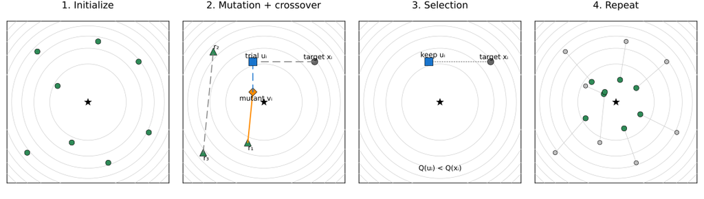

Figure 11: Differential Evolution initializes a population, creates a mutant from three donors, crosses the mutant with a target to form a trial, selects between the target and trial, and repeats.

**Algorithm: Differential Evolution**

- **Input:** A bounded objective $Q$, a population, a mutation scale $F$, a crossover probability $C_R$, and a maximum generation count.
- For each target $x_i^{(t)}$, choose distinct indices $r_1,r_2,r_3\neq i$ and construct the mutant:

$$v_i^{(t)}
=
x_{r_1}^{(t)}
+F\left(x_{r_2}^{(t)}-x_{r_3}^{(t)}\right).$$

- For a random coordinate $j_{\mathrm{rand}}$, form the trial point:

$$u_{ij}^{(t)}
=
\begin{cases}
v_{ij}^{(t)}, &
r_{ij}\leq C_R
\ \text{or}\
j=j_{\mathrm{rand}},\\
x_{ij}^{(t)}, & \text{otherwise},
\end{cases}
\qquad
r_{ij}\sim U(0,1).$$

- Apply one-to-one selection:

$$x_i^{(t+1)}
=
\begin{cases}
u_i^{(t)}, & Q(u_i^{(t)})\leq Q(x_i^{(t)}),\\
x_i^{(t)}, & \text{otherwise}.
\end{cases}$$

- Stop at the generation or evaluation budget and return the population member with the smallest objective value.
- **Output:** The approximate global minimizer, objective value, evaluation count, and solver status.
- **Example problem:** minimize the same bounded Rastrigin function.

#### SHADE

- **Problem with standard DE:** fixed $F$ and $C_R$ can be sensitive to the objective and to the current search stage.
- **Idea:** SHADE records successful values of $F$ and $C_R$, samples future values from that history, and uses a p-best mutation with an archive to preserve diversity.
- SHADE therefore changes how the mutation and crossover parameters are chosen; the trial construction and one-to-one selection still follow the DE logic.
- **Package example:** the [DifferentialEvolution.jl](https://github.com/kosukeshimamoto/DifferentialEvolution) package provides both `:de` and `:shade`:

```julia
import DifferentialEvolution
using Random

de_result = DifferentialEvolution.optimize(
    rastrigin_objective,
    [-5.0, -5.0],
    [5.0, 5.0];
    rng = MersenneTwister(42),
    algorithm = :de,
    maxiters = 200,
)

shade_result = DifferentialEvolution.optimize(
    rastrigin_objective,
    [-5.0, -5.0],
    [5.0, 5.0];
    rng = MersenneTwister(42),
    algorithm = :shade,
    maxiters = 200,
)

@show de_result.best_x de_result.best_f
@show shade_result.best_x shade_result.best_f
```

[output not shown]

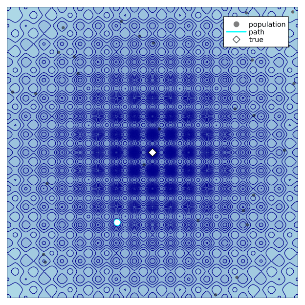

DE on the Rastrigin function.

[figure not shown]

SHADE on the Rastrigin function.

**Package note**

- DE is a useful and effective method. This Julia package is my implementation, but I have not been able to develop it actively recently.
- Comments and pull requests are welcome.

## Reference

- Miranda, M. J., and Fackler, P. L. (2002), *Applied Computational Economics and Finance*.
- Judd, K. L., [Numerical Methods in Economics](https://kenjudd.org/teaching/numerical-methods-by-judd/), Lectures 4–7.
- Train, K. E. (2009), [*Discrete Choice Methods with Simulation*](https://eml.berkeley.edu/books/choice2.html), Chapter 8.
- Storn, R., and Price, K. (1997), [*Differential Evolution: A Simple and Efficient Heuristic for Global Optimization over Continuous Spaces*](https://doi.org/10.1023/A:1008202821328).
- Tanabe, R., and Fukunaga, A. (2013), [*Evaluating the Performance of SHADE on CEC 2013 Benchmark Problems*](https://doi.org/10.1109/CEC.2013.6557798).
- Shimamoto, K., [DifferentialEvolution.jl](https://github.com/kosukeshimamoto/DifferentialEvolution).